# Comparison of short read aligners for ChIP-Seq

## Reference Data

MSL2 ChIP-Seq in D. melanogaster from https://doi.org/10.1101/gr.146407.112. We expect binding only to the X chromosome therefore we can use this as a prior knowledge system for evaluation of various analysis procedures.

Single read sequencing of IP and input on Illumina Genome Analyzer II, about 60 Mio reads each. Data downloaded on master node of the HPC using the aspera client via prefetch

```bash
module load ngs/sratoolkit/2.8.0

prefetch SRR495368 #IP
prefetch SRR495378 #input

fastq-dump SRR495368
fastq-dump SRR495378
```

- aligners used were
  - bowtie1 version 1.1.2
  - bowtie2 version 2.2.9
  - bwa version 0.7.16
  - STAR version 2.5.3a

## Alignment Code

1. **bowtie** with default settings

```bash
bowtie ${INDEX} -S -p ${NO_CORES}  ${FILEID}.fastq | samtools view -bS -o ${FILEID}.bam
samtools sort -m 2G -@ ${NO_CORES} -o ${FILEID}.s.bam ${FILEID}.bam
```

2. **bowtie** reporting only uniquely mapped reads

```bash
bowtie ${INDEX} -S -m 1 -p ${NO_CORES} ${FILEID}.fastq | samtools view -bS -o ${FILEID}.bam
samtools sort -m 2G -@ ${NO_CORES} -o ${FILEID}.s.bam ${FILEID}.bam
```

3. **bowtie2** with default settings

```bash
bowtie2 -p ${NO_CORES} -x ${INDEX} -U ${FILEID}.fastq | samtools view -bS -o ${FILEID}.bam
samtools sort -m 2G -@ ${NO_CORES} -o ${FILEID}.s.bam ${FILEID}.bam
```

4. **bowtie2** reporting only uniquely mapped reads

```bash
bowtie2 -p ${NO_CORES} -x ${INDEX} -U ${FILEID}.fastq > ${FILEID}.sam
samtools view -h ${FILEID}.sam | grep -v "XS:i:" | samtools view -b -o ${FILEID}.bam
samtools sort -m 2G -@ ${NO_CORES} -o ${FILEID}.s.bam ${FILEID}.bam
```

```bash
bowtie2 -p ${NO_CORES} -x ${INDEX} -U ${FILEID}.fastq | samtools view -bS -q 2 -o ${FILEID}.bam
samtools sort -m 2G -@ ${no_cores} -o ${FILEID}.s.bam ${FILEID}.bam
```

6. **bwa mem** with default settings

```bash
bwa mem -t ${NO_CORES} ${INDEX} ${FILEID}.fastq | samtools view -bS -o ${FILEID}.bam
samtools sort -m 2G -@ ${NO_CORES} -o ${FILEID}.s.bam ${FILEID}.bam
```

7. **bwa mem** reporting only uniquely mapped reads

```bash
bwa mem -t -c 1 ${NO_CORES} ${INDEX} ${FILEID}.fastq | samtools view -bS -o ${FILEID}.bam
samtools sort -m 2G -@ ${NO_CORES} -o ${FILEID}.s.bam ${FILEID}.bam
```

8. **bwa aln** with default settings

```bash
bwa aln -t ${NO_CORES} ${INDEX} ${FILEID}.fastq > ${FILEID}.sai
bwa samse ${INDEX} ${FILEID}.sai ${FILEID}.fastq | samtools view -bS -o ${FILEID}.bam
samtools sort -m 2G -@ ${NO_CORES} -o ${FILEID}.s.bam ${FILEID}.bam
```

9. **STAR** with some customization

```bash
STAR --runThreadN ${NO_CORES}  \
        --genomeDir ${INDEX} \
            --readFilesIn ${FILEID}.fastq \
                    --alignIntronMax 1 \
                        --alignEndsType EndToEnd \
                            --outSAMtype BAM SortedByCoordinate
```

10. **STAR** reporting only uniquely mapped reads

```bash
STAR --runThreadN ${NO_CORES}  \
        --genomeDir ${INDEX} \
            --readFilesIn ${FILEID}.fastq \
                    --alignIntronMax 1 \
                        --alignEndsType EndToEnd \
                            --outSAMtype BAM SortedByCoordinate
                        --outFilterMultimapNmax 1 \
```

## Execution Time

Calculated from start of alignment until end of BAM file sorting. Owing the direct sorting capability of STAR.

```r
readRDS("methods.rds")
```

```
##               name execution.time..ms.
## 1  bowtie1_default                 624
## 2   bowtie1_unique                 583
## 3  bowtie2_default                 615
## 10      bowtie2_q0                 618
## 4   bowtie2_unique                 566
## 7          bwa_aln                1157
## 5          bwa_mem                 574
## 6   bwa_mem_unique                 601
## 8             STAR                 178
## 9      STAR_unique                 162
```

## Coverages from BAM

Form each BAM file coverage object were generated after extending the reads in 3’ direction up to 200 bases. This was performed on the cluster.

```r
library(ShortRead)
library(rtracklayer)
library(GenomicRanges)
options(scipen=100)
gr <- readGAlignments(bam.file)
grs <- as(gr, "GRanges")
grsr <- resize(grs, 200)
covs <- coverage(grsr)
saveRDS(covs, file=sub(".bam", "_covs.rds",f))
gd <- as(covs, "RangedData")
export.bedGraph(gd, sub(".bam",".wig",f))
```

All coverages are read into one list of coverages.

```r
suppressPackageStartupMessages({
  library(gdata)
  library(RColorBrewer)
  library(GenomicFeatures)
  library(tsTools)
})

covs <- list.files(".","*_covs.rds")

sample <- sapply(covs, function(x){strsplit(x, "\\.")[[1]][1]})
alignType <- sub("_covs","",sapply(covs, function(x){strsplit(x, "\\.")[[1]][2]}))

adf <- data.frame(file=covs)
adf$sampleType <- ifelse(sample=="SRR495368", "IP", "input")
adf$alignType <- alignType

o <- order(adf$alignType, adf$sampleType)
adf <- adf[o,]
adf
```

```
##                                  file sampleType       alignType
## 11 SRR495378.bowtie1_default_covs.rds      input bowtie1_default
## 1  SRR495368.bowtie1_default_covs.rds         IP bowtie1_default
## 12  SRR495378.bowtie1_unique_covs.rds      input  bowtie1_unique
## 2   SRR495368.bowtie1_unique_covs.rds         IP  bowtie1_unique
## 13 SRR495378.bowtie2_default_covs.rds      input bowtie2_default
## 3  SRR495368.bowtie2_default_covs.rds         IP bowtie2_default
## 14      SRR495378.bowtie2_q0_covs.rds      input      bowtie2_q0
## 4       SRR495368.bowtie2_q0_covs.rds         IP      bowtie2_q0
## 15  SRR495378.bowtie2_unique_covs.rds      input  bowtie2_unique
## 5   SRR495368.bowtie2_unique_covs.rds         IP  bowtie2_unique
## 16         SRR495378.bwa_aln_covs.rds      input         bwa_aln
## 6          SRR495368.bwa_aln_covs.rds         IP         bwa_aln
## 17         SRR495378.bwa_mem_covs.rds      input         bwa_mem
## 7          SRR495368.bwa_mem_covs.rds         IP         bwa_mem
## 18  SRR495378.bwa_mem_unique_covs.rds      input  bwa_mem_unique
## 8   SRR495368.bwa_mem_unique_covs.rds         IP  bwa_mem_unique
## 19            SRR495378.STAR_covs.rds      input            STAR
## 9             SRR495368.STAR_covs.rds         IP            STAR
## 20     SRR495378.STAR_unique_covs.rds      input     STAR_unique
## 10     SRR495368.STAR_unique_covs.rds         IP     STAR_unique
```

```r
covList <- list()
for (cov in adf$file) {
  covList[[cov]] <- readRDS(cov)
}

names(covList) <- paste(adf$alignType, adf$sampleType)
```

# Signals in a Representative Region of ChrX

```r
txdb <- makeTxDbFromGFF("/Users/tobiasst/Desktop/mount/work/data/genomes/fly/Drosophila_melanogaster/UCSC/dm6/Annotation/Archives/archive-2015-07-24-09-25-49/Genes/genes.gtf")
```

```
## Import genomic features from the file as a GRanges object ... OK
## Prepare the 'metadata' data frame ... OK
## Make the TxDb object ... OK
```

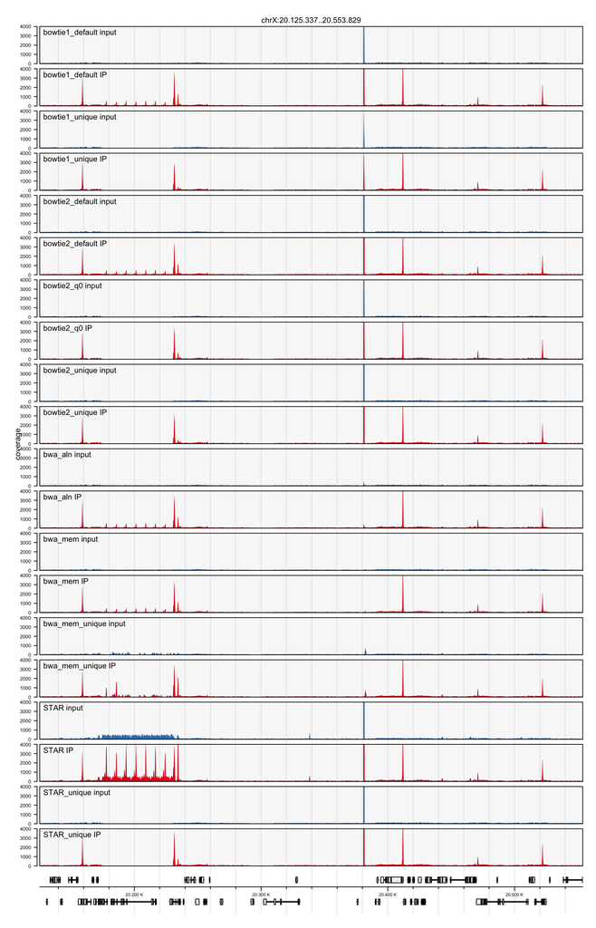

```r
cols <- rep(brewer.pal(8, "Set1")[c(2,1)],10)
lim <- c(0,4000)
lims <- rep(list(lim),20)

chr <- "chrX"
start <- 20125337
end <- 20553829

plotProfiles(start,end,chr,profs=covList,txdb=txdb,collapse=T, plot.labels=F, cols=cols, grid=T, ylims=lims,ylab="coverage")
```

# Signal in Peaks Regions

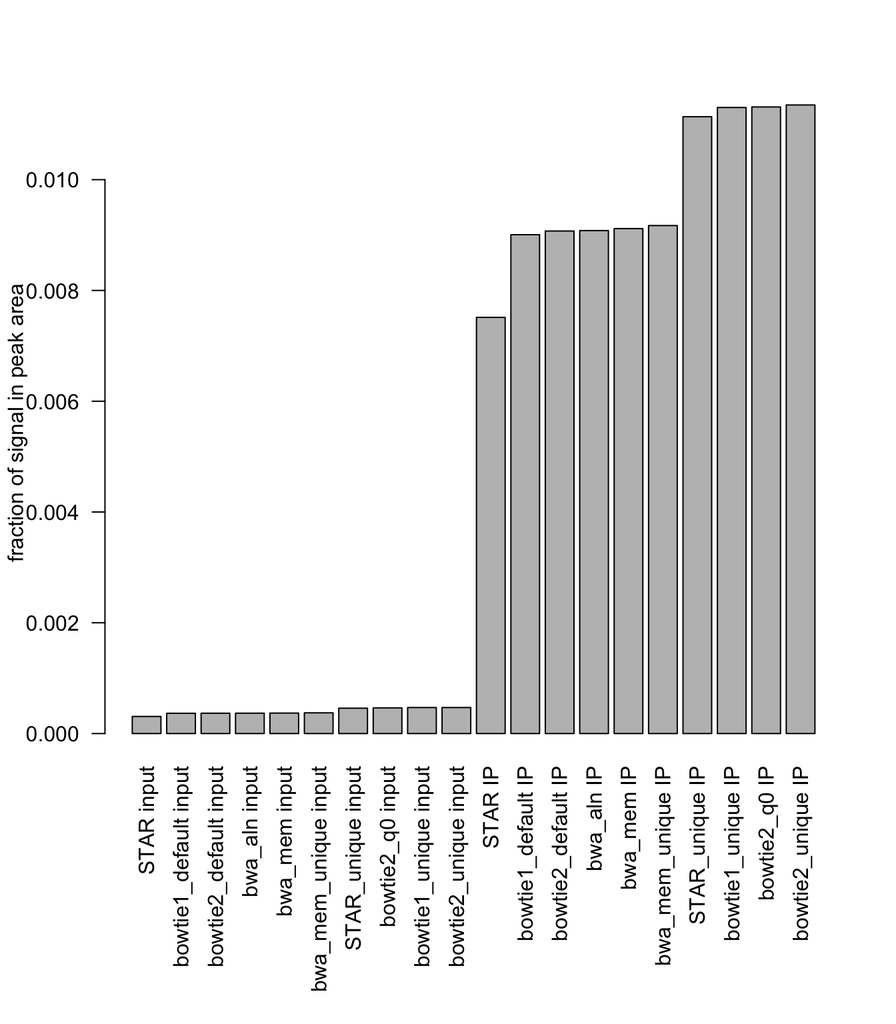

```r
peaks <- read.delim("msl2_in_vivo_peaks.bed", header=F)
colnames(peaks) <- c("chr","start","end")

peakSignals <- lapply(covList, function(x) {
  sum(unlist(lapply(names(x), function(y) {
    my.cov <- x[[y]]
    my.peaks <- peaks[peaks$chr==sub("chr","",y),]
    my.views <- Views(my.cov, start=my.peaks$start, end=my.peaks$end)
    sum(sum(my.views))
  })))
})

totalSignals <- lapply(covList, function(x) {
  sum(unlist(lapply(names(x), function(y) {
    my.cov <- x[[y]]
    sum(as.numeric(my.cov))
  })))
})

fracUnderPeak <- unlist(peakSignals)/unlist(totalSignals)
fracUnderPeak <- fracUnderPeak[order(fracUnderPeak)]

par(oma=c(6,0,0,0))
barplot(fracUnderPeak, las=2, ylab="fraction of signal in peak area")
```

# Number of Peaks

Peaks were called on aligned IP and input reads of each method.

```bash
#! /bin/bash
#
# homer.sbatch
#
#SBATCH -J homer                     # A single job name for the array
#SBATCH -p slim18                    # Partition
#SBATCH -n 9                         # 18 cores
#SBATCH -N 1                         # nodes required
#SBATCH -t 0-01:00                   # running time
#SBATCH --mem 10000                  # Memory request
#SBATCH -o homer_%A_%a.out       # Standard output
#SBATCH -e homer_%A_%a.err       # Standard error

module load ngs/Homer/4.9
module load ngs/samtools/1.3.1

makeTagDirectory ${method}_tag/ip/ SRR495368_out/SRR495368.${method}.bam -single
makeTagDirectory ${method}_tag/input/ SRR495378_out/SRR495378.${method}.bam -single

findPeaks ${method}_tag/ip/ -i ${method}_tag/input/ \
    -style factor -fragLength 200 -inputFragLength 200 \
    -F 2 -C 0 > ${method}_peaks.txt
pos2bed.pl ${method}_peaks.txt > ${method}_peaks.bed

rm -rf ${method}_tag
```

Distribution of X and autosomal peaks calculated in R

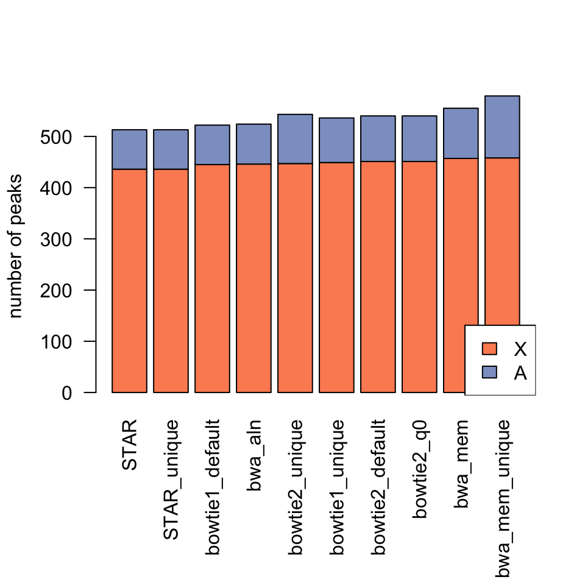

```r
mat <- Reduce(cbind,lapply(levels(as.factor(adf$alignType)), function(x) {
  read.delim(paste0("/Users/tobiasst/Desktop/mount/work/project/tobias/aligner_test/",x,"_peaks.bed"), comment.char = "#", header=F) -> peaks
  c(X=sum(peaks[,1]=="chrX"), A=sum(peaks[,1]!="chrX"))
}))
colnames(mat) <- levels(as.factor(adf$alignType))
o <- order(mat["X",])

cols <- brewer.pal(3, "Set2")[2:3]
par(oma=c(3,0,0,0))
barplot(mat[,o], las=2, col=cols, ylab="number of peaks")
legend("bottomright", c("X","A"), fill=cols)
```